# Analysis of Data Science Job Postings

Benjamin Ackerman

October 3, 2017

Perform an analysis of “data scientist” jobs listed on job boards and on the employment pages of major companies. What are the most common skills that employers look for? What are the most unique skills that employers look for? Where are the types of companies that employ the most data scientists?

## 1. Scrape Data from Job Search Boards

I have begun scraping data from [Stack Overflow](https://stackoverflow.com/jobs) by searching for jobs with the term “Data Scientist.” Here’s some of the data I’ve been able to extract:

| position | company | location | job_type | experience | industry | company_size | company_type | link |
| --- | --- | --- | --- | --- | --- | --- | --- | --- |
| Data Analyst | Jane.com | Lehi, UT | Permanent | Junior, Mid-Level | Retail Industry | 51-200 people | Private | https://stackoverflow.com/jobs/155681/data-analyst-janecom |
| Data Scientist | National Security Agency | Fort Meade, MD | Permanent | Mid-Level | Cybersecurity, Federal Agencies, Signals Analysis | 10k+ people | Public | https://stackoverflow.com/jobs/155241/data-scientist-national-security-agency |
| Data Scientist | Grindr | West Hollywood, CA | Permanent | Mid-Level | Big Data, Social Media, Software Development | 51-200 people | Private | https://stackoverflow.com/jobs/151199/data-scientist-grindr |
| Data Scientist | StreamDetroit | Ferndale, MI | Contract | Junior | Content Marketing, Digital Marketing, SaaS | 11-50 people | Private | https://stackoverflow.com/jobs/154094/data-scientist-streamdetroit |
| Data Scientist | BuzzFeed | Los Angeles, CA | Permanent | Mid-Level, Senior, Lead | Digital Media, Entertainment, News | 1k-5k people | VC Funded | https://stackoverflow.com/jobs/153762/data-scientist-buzzfeed |
| Data Scientist | PlentyOfFish Media ULC | Vancouver, BC, Canada | Permanent | Senior | Information Technology | 51-200 people | Public | https://stackoverflow.com/jobs/152134/data-scientist-plentyoffish-media-ulc |
| Lead Data Scientist | Careem | Berlin, Germany | Permanent | Senior, Lead, Manager | Software Development / Engineering, Transportation | 1k-5k people | VC Funded | https://stackoverflow.com/jobs/148268/lead-data-scientist-careem |
| Data Scientist / Engineer | SemanticBits | No office location | Permanent | NA | Digital Health | 51-200 people | NA | https://stackoverflow.com/jobs/141227/data-scientist-engineer-semanticbits |
| SQL Data Analyst | Detroit Trading Company | Birmingham, MI | Permanent | NA | Automotive | 51-200 people | Private | https://stackoverflow.com/jobs/151026/sql-data-analyst-detroit-trading-company |
| Business (Data) Analyst | Shane Co. | Centennial, CO | Permanent | Mid-Level | Consumer Products, Jewelry, Luxury Goods | 501-1k people | Private | https://stackoverflow.com/jobs/155412/business-data-analyst-shane-co |

There are 167 unique jobs listed on Stack Overflow that come up in my latest search.

In addition to the manual scraping I have performed, I have also received a database of jobs posted on Stack Overflow over the years from Dave Robinson, a Data Scientist at Stack Overflow. Per his request, the data will be kept private.

## 2. Visualize Job Postings by Location

Here, I visualize the Stack Overflow jobs using data provided from Dave Robinson. Markers are color coded by the year that they were posted. I use the function `geocode` from the `ggmaps` package to obtain latitude and longitude coordinates on the cities. I use code from [this repository](https://github.com/lmullen/mullenMisc/blob/master/R/jitter-latlong.R) to jitter the latitude and longitude, so that multiple points per city can be seen. The map is interactive: select data points by year to view the geographic trends in job listings!

[interactive chart not shown]

Here is a plot (yes, I figured out how to use `ggplot`…) that shows trends in number of jobs posted by US region over the past several years.

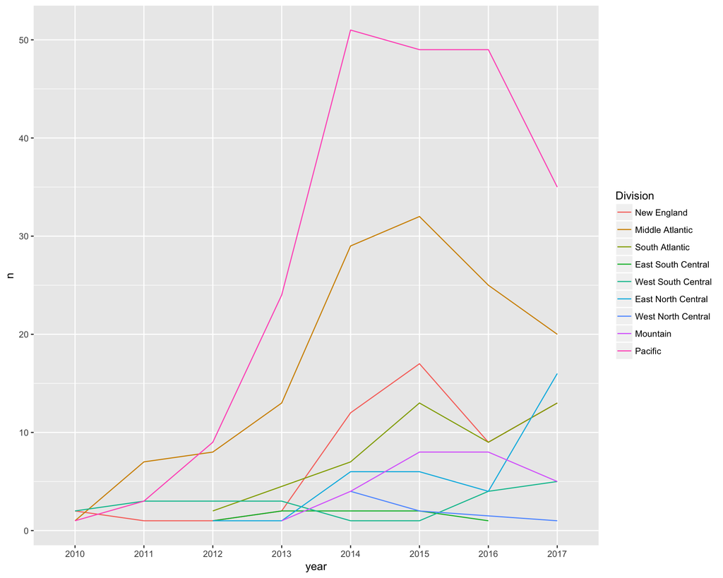

## 3. Skills that Employers are Looking For

Here is a word cloud of technical skill tags from the Stack Overflow job listings (data dump, not manual scraping):

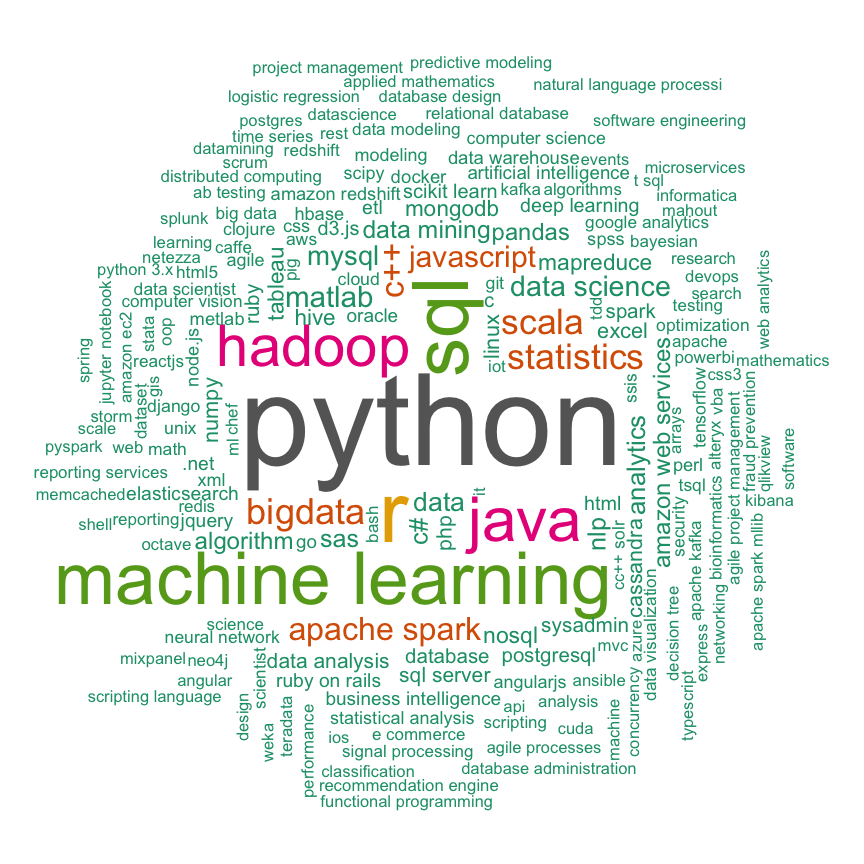

## More EDA:

Levels of Experience Requested

| Senior | Mid-Level | Lead | Junior | Manager | Student |
| --- | --- | --- | --- | --- | --- |
| 92 | 80 | 19 | 18 | 10 | 6 |

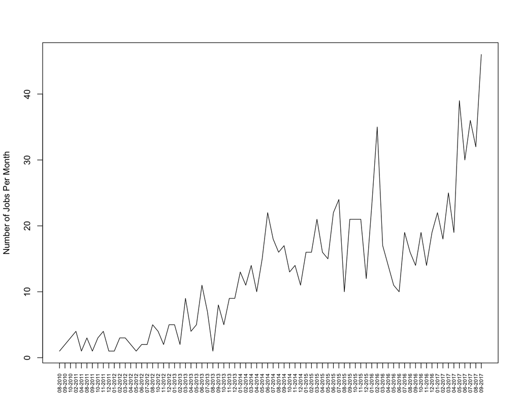

Months with the fewest job postings by year

| month | year | n |
| --- | --- | --- |
| 08 | 2010 | 1 |
| 04 | 2011 | 1 |
| 01 | 2012 | 1 |
| 08 | 2013 | 1 |
| 04 | 2014 | 10 |
| 08 | 2015 | 10 |
| 06 | 2016 | 10 |
| 02 | 2017 | 18 |

Months with the most job postings by year

| month | year | n |
| --- | --- | --- |
| 10 | 2010 | 3 |
| 02 | 2011 | 4 |
| 08 | 2012 | 5 |
| 06 | 2013 | 11 |
| 06 | 2014 | 22 |
| 07 | 2015 | 24 |
| 02 | 2016 | 35 |
| 09 | 2017 | 46 |

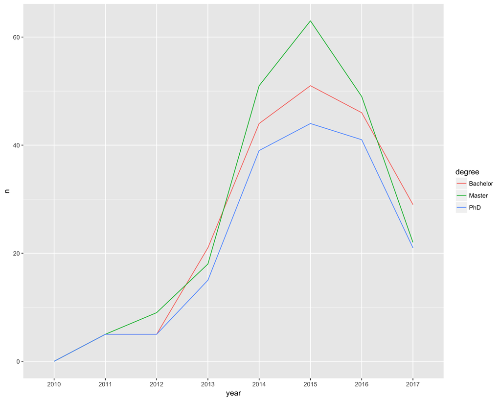

10 most common majors listed in job postings

| Major | n |
| --- | --- |
| Computer Science | 332 |
| Statistics | 300 |
| Engineering | 179 |
| Mathematics | 147 |
| Physics | 81 |
| Applied Mathematics | 54 |
| Intelligence | 46 |
| Operations Research | 38 |
| Bioinformatics | 12 |
| Artificial Intelligence | 11 |

## Things to do next:

- *start writing* - write up introduction/methods used
  - Introduction: Increased demand for data scientists, hot new field, Stack Overflow’s popularity
  - Methods
  - Data: Web scraping, data obtained directly from SO
  - Results
  - Discussion/Limitations
- scrape data from skills section:
  - **Get Degree Program info from Descriptions**
  - unique skill requests
  - more programming skills

### Analysis Plan:

- Look at trends in programming over time (while jobs only last about 4 weeks on Stack Overflow, I now have access to 8 years of postings…)
  - consider limitation: hiring season/scraping bias
  - undersampling/length bias - jobs in higher demand
- PCA clustering - skills by sector
- Are the public companies more likely to post more jobs? Private companies? Bigger companies?
- Compare job postings from two different job boards

### Limitations:

- Reproducibility issue: data are unique to when they are scraped, and I’m obtaining data from a data dump
  - list when data were pulled in report, save csv
  - one option: scrape data every so often, saving csv files, take union of rows to maximize number of postings
- Maybe not generalizable: potential bias in just looking at Stack Overflow, could attract job postings from certain types of industries